# An Extended Commentary On Post-Publication Peer Review In Organizational Neuroscience

In press at Meta-Psychology

[Guy A. Prochilo](https://www.guyprochilo.com)

April 27, 2019

- This R Markdown document reproduces the analyses found in the above publication and provides instructions for independent reproduction.
- A pre-print of this publication can be found at: https://psyarxiv.com/hv3rm
- Click [here](https://osf.io/ayuxz/) for a full history of the submission to [*Meta-Psychology*](https://open.lnu.se/index.php/metapsychology/about)

# 1 Instructions

Follow these instructions to independently reproduce all analyses in the above publication via an R Markdown file.

**1. Install requisite software:**

- R (v-3.5.1)
- R Studio (v-1.1.463)

*Note*: These analyses were performed using using Windows 10 and have not been tested on Unix systems.

**2. Download the analysis pipeline:**

- Download or clone the git repository for this analysis: https://github.com/gprochilo/org_neuro_com
- The files within this repository must be saved to a single directory

**3. Open the R Studio project file:**

- Open `analysis.Rproj` to begin an R Studio session in your current working directory

**4. Install the required packages**

- This analysis pipeline requires the following packages:

```r
install.packages("ggplot2")
install.packages("scales")
install.packages("ggrepel")
install.packages("ggpubr")
install.packages("psych")
install.packages("cocor")
install.packages("pbapply")
install.packages("reshape2")
install.packages("userfriendlyscience")
install.packages("devtools")
install.packages("SuppDists")
install.packages("here")
```

- The cannonball package can be installed from Github after installing devtools.

```r
install_github("janhove/cannonball")
```

**5. Knit the R Markdown file to reproduce all analyses:**

- Open `markdown.rmd` in R Studio and select **Knit**
- This action will reproduce this document and all associated analyses

# 2 Prepare R Workspace

The scripts below are evaluated by R Markdown to reproduce all analyses.

**1. Load and attach required packages**

- R Markdown will load and attach the required packages by sourcing the `libraries.R` file

```r
source("libraries.R")
```

**2. Source the analysis scripts**

- R Markdown will source the analysis script file for this project: `ProchFun_ONC-v2.R`
- This file includes all scripts required for reproducing all analyses

```r
source("ProcFun_ONC-v2.R")
```

[output not shown]

# 3 Reproduce Figures

## 3.1 Figure 1

- Reproduce the dot plot presented in Figure 1

```
## $mu
## [1] 74.73333
##
## $stdev
## [1] 49.62497
##
## $range
## [1] "6 to 177"
##
## $quants
##   10%   20%   30%   40%   50%   60%   70%   80%   90%
##  21.6  30.4  33.2  54.2  75.0  92.0  98.8 112.4 130.2
```

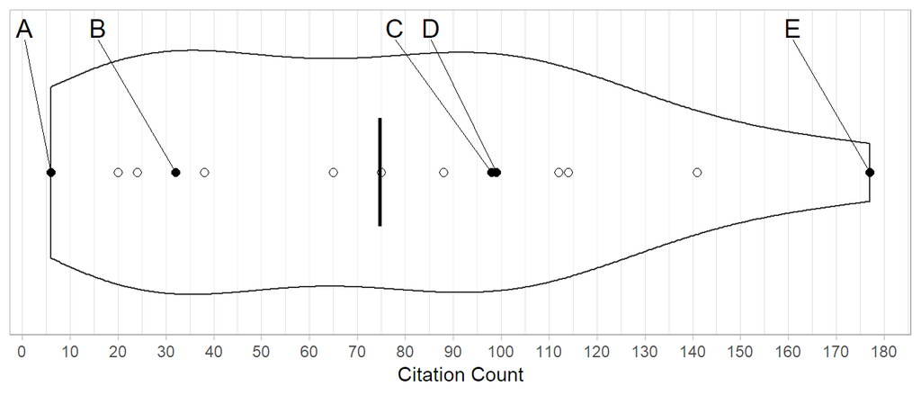

```
## [1] "EPS and PNG files generated."
```

```r
cite.plot()
```

## 3.2 Figure 2

- Reproduce scatterplots consistent with *r* = 0.36 and *N* = 50
- Note 1: The software outputs *N* rather than *df* in the title (this has been adjusted in the associated publication)
- Note 2: While the software outputs 16 scatterplots, eight scatterplots were included in the final publication due to space constraints

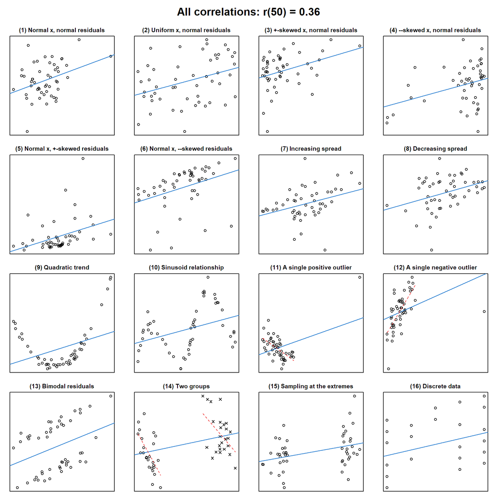

```
## [1] "EPS and PNG files generated."
```

```r
plot.r(r = 0.36, n = 50, plot = TRUE)
```

## 3.3 Figure 3

- Reproduce Figure 3A and Figure 3B
- Figure 3A (upper) is graphical representation of *r* = .26 and *r* = .36 and their 95% CIs with a sample of *N* = 50
- Figure 3B (lower) is the results of Zou’s test.

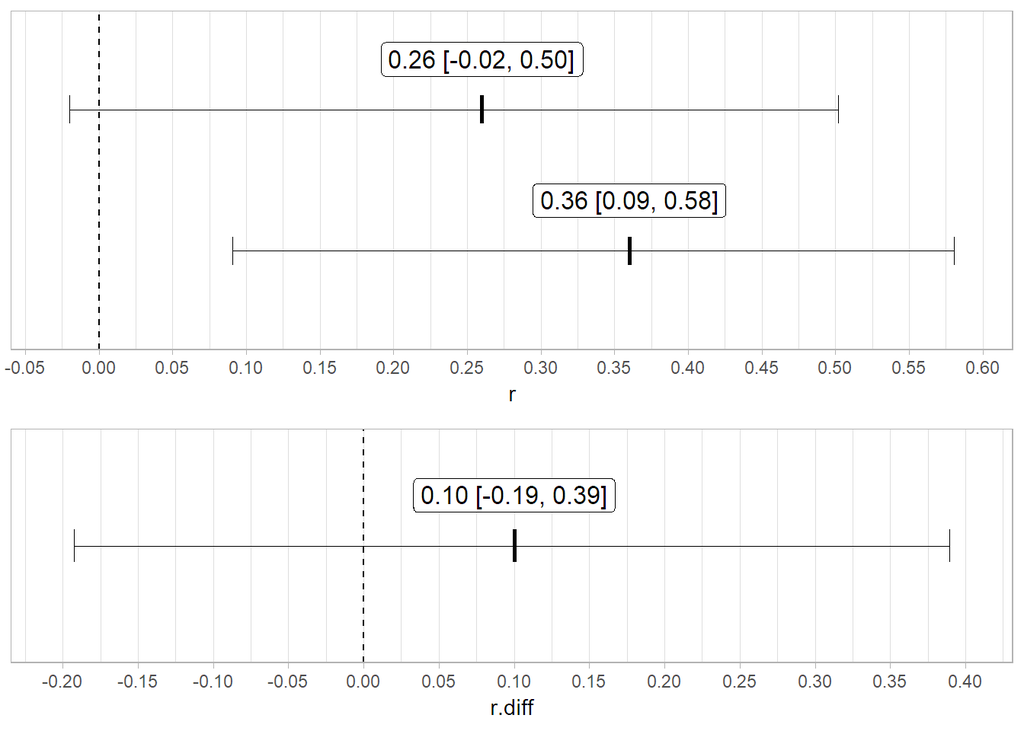

```
## [1] "EPS and PNG files generated."
```

```
## $r.jk
## [1] "0.36 [0.09, 0.58]"
##
## $r.jh
## [1] "0.26 [-0.02, 0.50]"
##
## $r.diff
## [1] "0.10 [-0.19, 0.39]"
```

```r
zou.test(
  r.jk=.36,
  r.jh=.26,
  r.kh=.39,
  n=50,
  twotailed = TRUE,
  alpha=0.05,
  conf.level=0.95,
  null.value=0,
  plot = TRUE
)
```

## 3.4 Figure 4

- Reproduce the simulation presented in Figure 4 and its associated dataset.
- The code in this R Markdown file uses a CSV file that contains the data generated by the simulation instead of running the simulation itself
- To run the full simulation you may run the following scripts outside of the R Markdown environment (runtime approx. 2-3 min):

```r
source("libraries.R")
source("ProchFun_ONC-v2.R")
errorPlot(comparisons = 50,sampleSize = 17,reps = 10000,plotname = "errorPlot", n.comparison.label = 20)
```

- The following code generates Figure 4 using a CSV file of data saved from the above simulation:

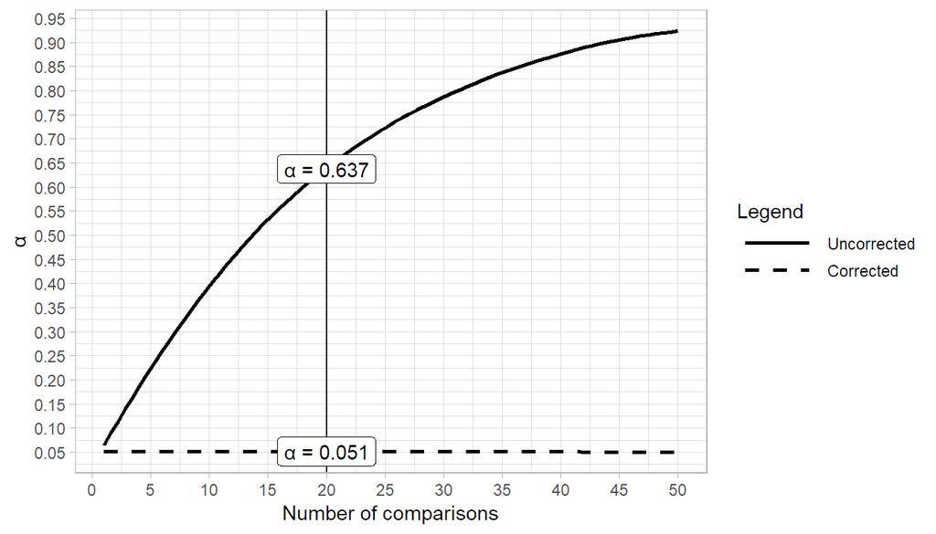

```
## [1] "EPS and PNG files generated."
```

```
##     comparisons      status  alpha
## 1             1 uncorrected 0.0494
## 2             2 uncorrected 0.0990
## 3             3 uncorrected 0.1445
## 4             4 uncorrected 0.1884
## 5             5 uncorrected 0.2276
## 6             6 uncorrected 0.2691
## 7             7 uncorrected 0.3057
## 8             8 uncorrected 0.3366
## 9             9 uncorrected 0.3673
## 10           10 uncorrected 0.3978
## 11           11 uncorrected 0.4261
## 12           12 uncorrected 0.4545
## 13           13 uncorrected 0.4848
## 14           14 uncorrected 0.5106
```

[output cut: 86 more lines]

```r
errorPlot.lazy("figure_4_data.csv", n.comparison.label = 20)
```

# 4 Waldman et al. (2011a)

## 4.1 Confidence interval computations

### 4.1.1 *r*(48) = 0.36, *p* < .05

```r
r.confidence(0.36,50,twotailed = TRUE)
```

```
## $result
## [1] "r(48) = 0.36 [0.09, 0.58], p = 0.010"
```

```
## $r
## [1] 0.36
##
## $n
## [1] 50
##
## $df
## [1] 48
##
## $ci.lower
## [1] 0.09074545
##
## $ci.upper
## [1] 0.5802079
##
## $ci.width
## [1] 0.4894624
##
## $MarginOfError
## [1] 0.2447312
##
## $t.val
## [1] 2.673398
##
## $p.val
## [1] 0.01023068
```

### 4.1.2 *r*(48) = 0.26, *p* < .10

```r
r.confidence(0.26,50,twotailed = TRUE)
```

```
## $result
## [1] "r(48) = 0.26 [-0.02, 0.50], p = 0.068"
```

```
## $r
## [1] 0.26
##
## $n
## [1] 50
##
## $df
## [1] 48
##
## $ci.lower
## [1] -0.01977914
##
## $ci.upper
## [1] 0.5020166
##
## $ci.width
## [1] 0.5217957
##
## $MarginOfError
## [1] 0.2608979
##
## $t.val
## [1] 1.86549
##
## $p.val
## [1] 0.06823097
```

## 4.2 Zou’s test

```r
zou.test(
  r.jk=.36,
  r.jh=.26,
  r.kh=.39,
  n=50,
  twotailed = TRUE,
  alpha=0.05,
  conf.level=0.95,
  null.value=0,
  plot = FALSE,
  save.plot = FALSE
)
```

```
## $r.jk
## [1] "0.36 [0.09, 0.58]"
##
## $r.jh
## [1] "0.26 [-0.02, 0.50]"
##
## $r.diff
## [1] "0.10 [-0.19, 0.39]"
```

## 4.3 Precision for planning

### 4.3.1 *r* = 0.36 and margin of error = 0.18 with 95% confidence

```r
pwr.confIntR(r = 0.36, w = 0.18, conf.level = 0.95)
```

```
##          w = 0.18
## r = 0.36       92
## attr(,"conf.level")
## [1] 0.95
```

### 4.3.2 *r* = 0.09 and margin of error = 0.045 with 95% confidence

```r
pwr.confIntR(r = 0.09, w = 0.045, conf.level = 0.95)
```

```
##          w = 0.045
## r = 0.09      1867
## attr(,"conf.level")
## [1] 0.95
```

# 5 Waldman et al. (2013a)

## 5.1 Confidence interval computations

```r
r.confidence(0.32,26,twotailed = TRUE)
```

```
## $result
## [1] "r(24) = 0.32 [-0.08, 0.63], p = 0.111"
```

```
## $r
## [1] 0.32
##
## $n
## [1] 26
##
## $df
## [1] 24
##
## $ci.lower
## [1] -0.07688162
##
## $ci.upper
## [1] 0.6293432
##
## $ci.width
## [1] 0.7062248
##
## $MarginOfError
## [1] 0.3531124
##
## $t.val
## [1] 1.654681
##
## $p.val
## [1] 0.1110101
```

```r
r.confidence(0.32,26,twotailed = FALSE)
```

```
## $result
## [1] "r(24) = 0.32 [-0.01, 0.59], p = 0.056"
```

```
## $r
## [1] 0.32
##
## $n
## [1] 26
##
## $df
## [1] 24
##
## $ci.lower
## [1] -0.0113281
##
## $ci.upper
## [1] 0.5880125
##
## $ci.width
## [1] 0.5993406
##
## $MarginOfError
## [1] 0.2996703
##
## $t.val
## [1] 1.654681
##
## $p.val
## [1] 0.05550505
```

# 6 Kim and James (2015)

## 6.1 Confidence interval computations

```r
r.confidence(0.49,17,twotailed = TRUE)
```

```
## $result
## [1] "r(15) = 0.49 [0.01, 0.79], p = 0.046"
```

```
## $r
## [1] 0.49
##
## $n
## [1] 17
##
## $df
## [1] 15
##
## $ci.lower
## [1] 0.01223732
##
## $ci.upper
## [1] 0.785619
##
## $ci.width
## [1] 0.7733817
##
## $MarginOfError
## [1] 0.3866908
##
## $t.val
## [1] 2.177025
##
## $p.val
## [1] 0.04585992
```

## 6.2 Critical *r* computations

### 6.2.1 Critical *r* value for a study with *N* = 17

```r
critical.r(n = 17, alpha = .05, twotailed = TRUE)
```

```
## $t.crit
## [1] 2.13145
##
## $r.crit
## [1] 0.482146
```